# Deep feedforward neural networks

Press the button 'Toggle code' below to toggle code on and off for entire this presentation.

```python
from IPython.display import display
from IPython.display import HTML
import IPython.core.display as di # Example: di.display_html('<h3>%s:</h3>' % str, raw=True)

# This line will hide code by default when the notebook is eåxported as HTML
di.display_html('<script>jQuery(function() {if (jQuery("body.notebook_app").length == 0) { jQuery(".input_area").toggle(); jQuery(".prompt").toggle();}});</script>', raw=True)

# This line will add a button to toggle visibility of code blocks, for use with the HTML export version
di.display_html('''<button onclick="jQuery('.input_area').toggle(); jQuery('.prompt').toggle();">Toggle code</button>''', raw=True)
```

# 1. Neural network basis functions

## 1.1 Single-input single-layer basis functions

\begin{equation} f\left(x\right)=a\left(w_0+w_1\,x\right) \end{equation}

- $a\left(\cdot\right)$ is the nonlinear *activation function*. Popular choices include $\text{tanh}(\cdot)$ and $\text{max}\left(0,\cdot\right)$.
- $w_0$ and $w_1$ are tunable weights.
- Because each single-layer network function has *tunable internal parameters* a single element can take on a variety of shapes.

#### Example 1. Single-layers basis elements with $\text{tanh}$ activation

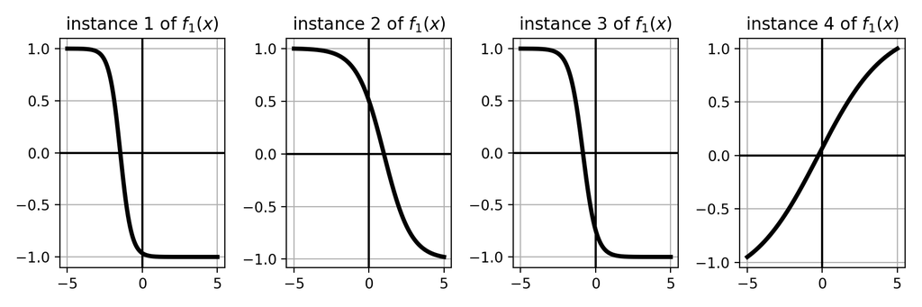

```python
# import Draw_Bases class for visualizing various basis element types
demo = nonlib.DrawBases.Visualizer()

# plot the first 4 elements of the polynomial basis
demo.show_1d_net(num_layers = 1, activation = 'tanh')
```

#### Example 2. Single-layers basis elements with ReLU activation

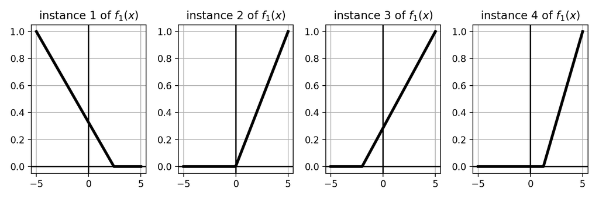

```python
# import Draw_Bases class for visualizing various basis element types
demo = nonlib.DrawBases.Visualizer()

# plot the first 4 elements of the polynomial basis
demo.show_1d_net(num_layers = 1, activation = 'relu')
```

## 1.2 Single-input multi-layer basis functions

More flexible basis functions can be constructed via summation and composition of multiple activation functions.

We take a weighted sum of single-layer basis functions (plus a bias weight) and pass the result through an activation function of the same kind, to get a 2-layer basis function:

\begin{equation} f\left(x\right)=a\left(w^{\left(1\right)}_{0}+\underset{i}{\sum}{w^{\left(1\right)}_{i}}\,a\left(w^{\left(2\right)}_{i,0}+w^{\left(2\right)}_{i,1}\,x\right)\right) \end{equation}

Superscripts indicate the layer each internal parameter belongs to.

#### Example 3. 2-layer basis elements with $\text{tanh}$ activation

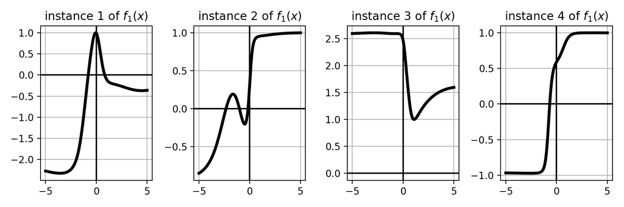

```python
# import Draw_Bases class for visualizing various basis element types
demo = nonlib.DrawBases.Visualizer()

# plot the first 4 elements of the polynomial basis
demo.show_1d_net(num_layers = 2,activation = 'tanh')
```

To achieve even greater flexibility we can simply repeat the summation/composition procedure.

A 3-layer basis function:

\begin{equation} f\left(x\right)=a\left(w^{\left(1\right)}_{0}+\underset{i}{\sum}{w^{\left(1\right)}_{i}}\,a\left(w^{\left(2\right)}_{i,0}+\underset{j}{\sum}{w^{\left(2\right)}_{i,j}}\,a\left(w^{\left(3\right)}_{j,0}+w^{\left(3\right)}_{j,1}\,x\right)\right)\right) \end{equation}

This procedure can be repeated to produce basis elements with an arbitrary number of layers.

Currently the convention is to refer to a basis element with three or more layers as a *deep* neural network basis.

#### Example 4. 10-layer basis elements with $\text{tanh}$ activation

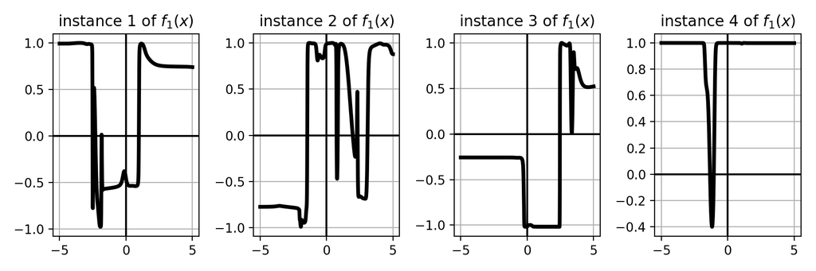

```python
# import Draw_Bases class for visualizing various basis element types
demo = nonlib.DrawBases.Visualizer()

# plot the first 4 elements of the polynomial basis
demo.show_1d_net(num_layers = 10, activation = 'tanh')
```

## 1.3 multi-input multi-layer basis functions

Extending the definition of neural network basis functions to allow for multiple inputs is straightforward: each input dimension gets its own tunable parameter.

For example: a 3-layer basis with $N$ dimensional input

\begin{equation} f\left(x_1,x_2,\ldots,x_N\right)=a\left(w^{\left(1\right)}_{0}+\underset{i}{\sum}{w^{\left(1\right)}_{i}}\,a\left(w^{\left(2\right)}_{i,0}+\underset{j}{\sum}{w^{\left(2\right)}_{i,j}}\,a\left(w^{\left(3\right)}_{j,0}+\underset{n}{\sum}w^{\left(3\right)}_{j,n}\,x_n\right)\right)\right) \end{equation}

## 2. Feedforward neural networks

Feedforward neural networks refer to nonlinear regressors or classifiers built using neural network basis functions.

For instance: a 3-layer regression network is given below where $f_m$'s are 3-layer basis functions.

\begin{equation} \text{predict}\left(x_1,x_2,\ldots,x_N\right)=w_{0}+\underset{m}{\sum}{w_{m}\,\,f_m\left(x_1,x_2,\ldots,x_N\right)} \end{equation}

Lets write down the full algebraic form:

\begin{equation} w_0+\underset{u_1=1}{\overset{U_1}{\sum}}w_{u_1}\,a\left(w^{\left(1\right)}_{u_1,0}+\underset{u_2=1}{\overset{U_2}{\sum}}{w^{\left(1\right)}_{u_1,u_2}}\,a\left(w^{\left(2\right)}_{u_2,0}+\underset{u_3=1}{\overset{U_3}{\sum}}{w^{\left(2\right)}_{u_2,u_3}}\,a\left(w^{\left(3\right)}_{u_3,0}+\underset{n=1}{\overset{N}{\sum}}w^{\left(3\right)}_{u_3,n}\,x_n\right)\right)\right) \end{equation}

There has to be a better way to do this!

### Renotate:

\begin{equation} \mathbf{x}=\left[\begin{array}{c} 1\\ x_{1}\\ \vdots\\ x_{N} \end{array}\right], \,\, \mathbf{w}_{0}=\left[\begin{array}{c} w_{0}\\ w_{1}\\ \vdots\\ w_{U_1} \end{array}\right], \,\, \mathbf{W}_{k}=\left[\begin{array}{cccc} w_{1,0}^{\left(k\right)} & w_{2,0}^{\left(k\right)} & \cdots & w_{U_{k},0}^{\left(k\right)}\\ w_{1,1}^{\left(k\right)} & w_{2,1}^{\left(k\right)} & \cdots & w_{U_{k},1}^{\left(k\right)}\\ \vdots & \vdots & \ddots & \vdots\\ w_{1,U_{k+1}}^{\left(k\right)} & w_{2,U_{k+1}}^{\left(k\right)} & \cdots & w_{U_{k},U_{k+1}}^{\left(k\right)} \end{array}\right],\,\, \mathbf{a}\left(\mathbf{v}\right)=\left[\begin{array}{c} 1\\ a\left(v_{1}\right)\\ \vdots\\ a\left(v_{d}\right) \end{array}\right] \end{equation}

**scalar notation:**

\begin{equation} w_0+\underset{u_1=1}{\overset{U_1}{\sum}}w_{u_1}\,a\left(w^{\left(1\right)}_{u_1,0}+\underset{u_2=1}{\overset{U_2}{\sum}}{w^{\left(1\right)}_{u_1,u_2}}\,a\left(w^{\left(2\right)}_{u_2,0}+\underset{u_3=1}{\overset{U_3}{\sum}}{w^{\left(2\right)}_{u_2,u_3}}\,a\left(w^{\left(3\right)}_{u_3,0}+\underset{n=1}{\overset{N}{\sum}}w^{\left(3\right)}_{u_3,n}\,x_n\right)\right)\right) \end{equation}

**vector/matrix notation:**

\begin{equation} \mathbf{w}_0^T\,\mathbf{a}\left(\mathbf{W}_1^T\, \mathbf{a}\left(\mathbf{W}_{2}^T\,\mathbf{a}\left(\mathbf{W}_{3}^T\,\mathbf{x}\right)\right)\right) \end{equation}

[figure not shown]

In general, a neural network regressor with $L$ layers takes the form:

\begin{equation} \text{predict}\left(\mathbf{x}\right)=\mathbf{w}_0^T\,\mathbf{a}\left(\mathbf{W}_1^T\, \mathbf{a}\,\left(\,\cdots\,\mathbf{W}_{L-1}^T\,\mathbf{a}\left(\mathbf{W}_{L}^T\,\mathbf{x}\right)\right)\right) \end{equation}

[figure not shown]

```
in_put = np.append([1], x)

for j in range(L,0,-1):
    in_put = np.dot(W[str(j)].T, in_put)
    out_put = np.tanh(in_put)
    out_put = np.append([1], out_put)

return np.dot(w0.T, out_put)
```